# Topic Modeling

## Topic modeling for 2020 Q4

```python
data_q4 = df_q4.clean_tweet.values.tolist()
data_q4_words = list(sent_to_words(data_q4))

# Create Dictionary
id2word_q4 = corpora.Dictionary(data_q4_words)
# Create Corpus
texts_q4 = data_q4_words
# Term Document Frequency
corpus_q4 = [id2word_q4.doc2bow(text) for text in texts_q4]
```

```python
from pprint import pprint
# number of topics
num_topics = 6
# Build LDA model
lda_model_q4 = gensim.models.LdaMulticore(corpus=corpus_q4,
                                       id2word=id2word_q4,
                                       num_topics=num_topics,
                                      random_state=123,
                                      passes=50,
                                       chunksize=50000)
# Print the Keyword in the k topics
#pprint(lda_model.print_topics())
#doc_lda = lda_model[corpus]
```

```python
# Compute Coherence Score
coherence_model_lda = CoherenceModel(model=lda_model_q4, texts=data_q4_words, dictionary=id2word_q4, coherence='c_v')
coherence_lda = coherence_model_lda.get_coherence()
print('\nCoherence Score: ', coherence_lda)
```

```
Coherence Score:  0.3088693571105344
```

```python
# Save the Modle to file in the current working directory
import pickle
Pkl_Filename = "Pickle_tm_q4_0415.pkl"

with open(Pkl_Filename, 'wb') as file:
    pickle.dump(lda_model_q4, file)

# Load the Model back from file

#Pkl_Filename = "Pickle_tm_q4.pkl"
#with open(Pkl_Filename, 'rb') as file:
    #lda_test = pickle.load(file)

# Compute Coherence Score
#coherence_model_lda = CoherenceModel(model=lda_test, texts=data_q4_words, dictionary=id2word_q4, coherence='c_v')
#coherence_lda = coherence_model_lda.get_coherence()
#print('\nCoherence Score: ', coherence_lda)
```

```python
# package to clean text
import re
import pyLDAvis.gensim
import pickle
import pyLDAvis
import os
```

```python
pyLDAvis.enable_notebook()
vis = pyLDAvis.gensim.prepare(lda_model_q4, corpus_q4, id2word_q4)
vis
```

[interactive chart not shown]

```python
Pkl_Filename = "Pickle_tm_q4.pkl"

with open(Pkl_Filename, 'rb') as file:
    lda_model_q4 = pickle.load(file)
```

```python
# assign topic probability to tweet
```

```python
pyLDAvis.save_html(vis,'result_q4.html')
```

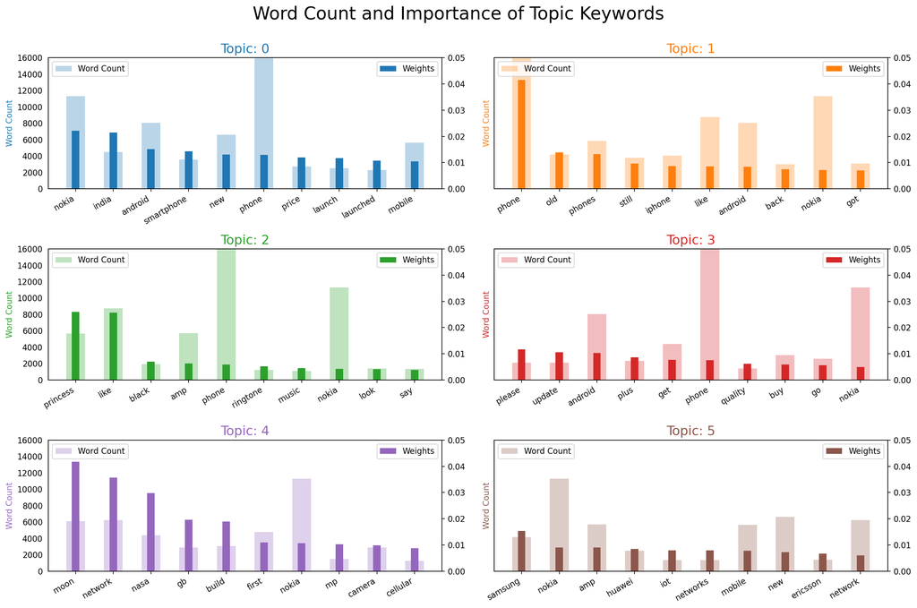

```python
from collections import Counter
import matplotlib.pyplot as plt
import matplotlib.colors as mcolors

topics = lda_model_q4.show_topics(formatted=False)
data_flat = [w for w_list in data_q4_words for w in w_list]
counter = Counter(data_flat)

out = []
for i, topic in topics:
    for word, weight in topic:
        out.append([word, i , weight, counter[word]])

df = pd.DataFrame(out, columns=['word', 'topic_id', 'importance', 'word_count'])

# Plot Word Count and Weights of Topic Keywords
fig, axes = plt.subplots(3, 2, figsize=(16,10), sharey=True, dpi=160)
cols = [color for name, color in mcolors.TABLEAU_COLORS.items()]
for i, ax in enumerate(axes.flatten()):
    ax.bar(x='word', height="word_count", data=df.loc[df.topic_id==i, :], color=cols[i], width=0.5, alpha=0.3, label='Word Count')
    ax_twin = ax.twinx()
    ax_twin.bar(x='word', height="importance", data=df.loc[df.topic_id==i, :], color=cols[i], width=0.2, label='Weights')
    ax.set_ylabel('Word Count', color=cols[i])
    ax_twin.set_ylim(0, 0.050); ax.set_ylim(0, 16000)
    ax.set_title('Topic: ' + str(i), color=cols[i], fontsize=16)
    ax.tick_params(axis='y', left=False)
    ax.set_xticklabels(df.loc[df.topic_id==i, 'word'], rotation=30, horizontalalignment= 'right')
    ax.legend(loc='upper left'); ax_twin.legend(loc='upper right')

fig.tight_layout(w_pad=2)
fig.suptitle('Word Count and Importance of Topic Keywords', fontsize=22, y=1.05)
plt.show()
```

## Q4 Topic:

Topic 0: Nokia smartphone launch in India market  
Topic 1: History/ Memory with Nokia  
Topic 2: Phone music application (princess + like)  
Topic 3: Android plus  
Topic 4: Nokia relase build the network on the moon  
Topic 5: Competitors like Samsung/Huawei

```python
data_q1 = df_q1.clean_tweet.values.tolist()
data_q1_words = list(sent_to_words(data_q1))

# Create Dictionary
id2word_q1 = corpora.Dictionary(data_q1_words)
# Create Corpus
texts_q1 = data_q1_words
# Term Document Frequency
corpus_q1 = [id2word_q1.doc2bow(text) for text in texts_q1]
```

```python
from pprint import pprint
# number of topics
num_topics = 6
# Build LDA model
lda_model_q1 = gensim.models.LdaMulticore(corpus=corpus_q1,
                                       id2word=id2word_q1,
                                       num_topics=num_topics,
                                      random_state=123,
                                      passes=50,
                                       chunksize=50000)
# Print the Keyword in the k topics
#pprint(lda_model.print_topics())
#doc_lda = lda_model[corpus]
```

```python
# Compute Coherence Score
coherence_model_lda_2 = CoherenceModel(model=lda_model_q1, texts=data_q1_words, dictionary=id2word_q1, coherence='c_v')
coherence_lda = coherence_model_lda_2.get_coherence()
print('\nCoherence Score: ', coherence_lda) #0.54076517
```

```
Coherence Score:  0.5407651709153406
```

```python
import warnings
warnings.filterwarnings('ignore')
```

```python
pyLDAvis.enable_notebook()
vis = pyLDAvis.gensim.prepare(lda_model_q1, corpus_q1, id2word_q1)
vis
```

[interactive chart not shown]

```python
pyLDAvis.save_html(vis,'result_q1.html')
```

```python
with open(Pkl_Filename, 'rb') as file:
    lda_test = pickle.load(file)
```

```python
# Save the Modle to file in the current working directory
import pickle
Pkl_Filename = "Pickle_tm_q1_0415.pkl"

with open(Pkl_Filename, 'wb') as file:
    pickle.dump(lda_model_q1, file)

# Load the Model back from file

#Pkl_Filename = "Pickle_tm_q1.pkl"

#with open(Pkl_Filename, 'rb') as file:
#    lda_model_q1 = pickle.load(file)
```

```python
Pkl_Filename = "Pickle_tm_q1.pkl"
with open(Pkl_Filename, 'rb') as file:
    lda_test = pickle.load(file)

# Compute Coherence Score
coherence_model_lda = CoherenceModel(model=lda_test, texts=data_q1_words, dictionary=id2word_q1, coherence='c_v')
coherence_lda = coherence_model_lda.get_coherence()
print('\nCoherence Score: ', coherence_lda)
```

```
Coherence Score:  0.5407651709153406
```

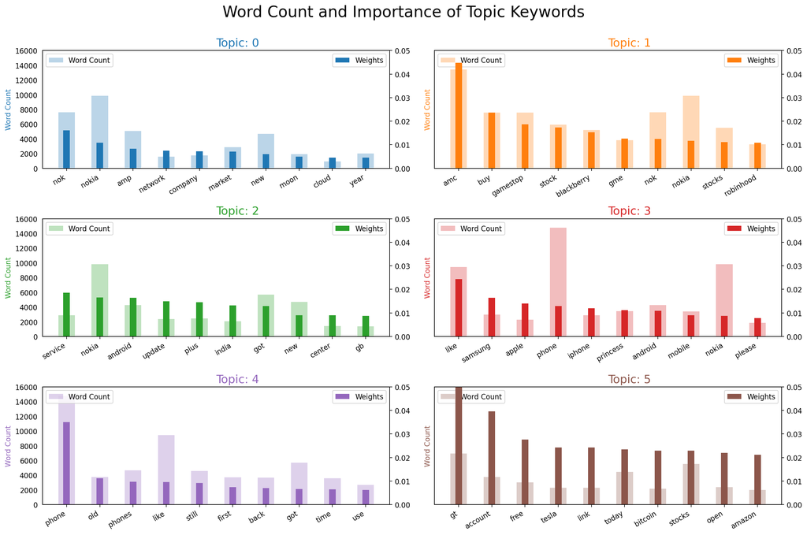

```python
from collections import Counter
import matplotlib.pyplot as plt
import matplotlib.colors as mcolors

topics = lda_model_q1.show_topics(formatted=False)
data_flat = [w for w_list in data_q1_words for w in w_list]
counter = Counter(data_flat)

out = []
for i, topic in topics:
    for word, weight in topic:
        out.append([word, i , weight, counter[word]])

df = pd.DataFrame(out, columns=['word', 'topic_id', 'importance', 'word_count'])

# Plot Word Count and Weights of Topic Keywords
fig, axes = plt.subplots(3, 2, figsize=(16,10), sharey=True, dpi=160)
cols = [color for name, color in mcolors.TABLEAU_COLORS.items()]
for i, ax in enumerate(axes.flatten()):
    ax.bar(x='word', height="word_count", data=df.loc[df.topic_id==i, :], color=cols[i], width=0.5, alpha=0.3, label='Word Count')
    ax_twin = ax.twinx()
    ax_twin.bar(x='word', height="importance", data=df.loc[df.topic_id==i, :], color=cols[i], width=0.2, label='Weights')
    ax.set_ylabel('Word Count', color=cols[i])
    ax_twin.set_ylim(0, 0.050); ax.set_ylim(0, 16000)
    ax.set_title('Topic: ' + str(i), color=cols[i], fontsize=16,ha='left')
    ax.tick_params(axis='y', left=False)
    ax.set_xticklabels(df.loc[df.topic_id==i, 'word'], rotation=30, horizontalalignment= 'right')
    ax.legend(loc='upper left'); ax_twin.legend(loc='upper right')

fig.tight_layout(w_pad=2)
fig.suptitle('Word Count and Importance of Topic Keywords', fontsize=22, y=1.05)
plt.show()
```

## 2021 Q1 Topic:

Topic 0: Nokia network market  
Topic 1: stock market :wsb/gme  
Topic 2: Android service update  
Topic 3: Competitors like Samsung/iphone  
Topic 4: Nokia history/memory  
Topic 5: gt is the character that prople share a link that twitter generated.

```python
all_topics = lda_model_q1.get_document_topics(corpus_q1, minimum_probability=0.0)
all_topics_csr = gensim.matutils.corpus2csc(all_topics)
all_topics_numpy = all_topics_csr.T.toarray()
all_topics_df = pd.DataFrame(all_topics_numpy)
```

```python
all_topics_df.shape
```

```
(121959, 6)
```

```python
all_topics_df.head()
```

|  | 0 | 1 | 2 | 3 | 4 | 5 |
| --- | --- | --- | --- | --- | --- | --- |
| 0 | 0.304418 | 0.647333 | 0.012005 | 0.012003 | 0.012089 | 0.012153 |
| 1 | 0.033470 | 0.033888 | 0.033341 | 0.033388 | 0.832572 | 0.033340 |
| 2 | 0.015296 | 0.923828 | 0.015166 | 0.015194 | 0.015311 | 0.015205 |
| 3 | 0.351403 | 0.121112 | 0.125102 | 0.019141 | 0.363999 | 0.019245 |
| 4 | 0.382029 | 0.418549 | 0.142977 | 0.018797 | 0.018871 | 0.018777 |

```python
len(data_q1)
```

```
121959
```

```python
all_topics_df = all_topics_df.apply(pd.to_numeric)
```

```python
df_q1['topic_label'] = all_topics_df.apply(lambda x: x.argmax(), axis=1)
```

```python
df_result1 = df_q1[['tweet','topic_label']]
```

```python
df_result1.to_csv('df_result1.csv',index = False)
```

```python
df_train = text[['topic_label','clean_tweet']]
```